# HW 03

Author

Yashi Mi

```r
# - loading package manager
if (!require(pacman))
  install.packages(pacman)
# - loading required packages
pacman::p_load(tidyverse,
               here,
               tibble,
               gt,
               reader,
               jpeg,
               grid,
               forcats)
```

## 1 - Du Bois challenge.

```r
income <- read_csv(here("data","income.csv"))
glimpse(income)
```

```
Rows: 7
Columns: 7
$ Class          <chr> "$100-200", "$200-300", "$300-400", "$400-500", "$500-7…
$ Average_Income <dbl> 139.10, 249.45, 335.66, 433.82, 547.00, 880.00, 1125.00
$ Rent           <dbl> 19, 22, 23, 18, 13, 0, 0
$ Food           <dbl> 43, 47, 43, 37, 31, 37, 29
$ Clothes        <dbl> 28, 23, 18, 15, 17, 19, 16
$ Tax            <dbl> 9.9, 4.0, 4.5, 5.5, 5.0, 8.0, 4.5
$ Other          <dbl> 0.1, 4.0, 11.5, 24.5, 34.0, 36.0, 50.5
```

```r
income_long <- income |>
  pivot_longer(cols = c("Rent","Food", "Clothes", "Tax","Other"),
               names_to = "category",
               values_to = "percentage")
glimpse(income)
```

```
Rows: 7
Columns: 7
$ Class          <chr> "$100-200", "$200-300", "$300-400", "$400-500", "$500-7…
$ Average_Income <dbl> 139.10, 249.45, 335.66, 433.82, 547.00, 880.00, 1125.00
$ Rent           <dbl> 19, 22, 23, 18, 13, 0, 0
$ Food           <dbl> 43, 47, 43, 37, 31, 37, 29
$ Clothes        <dbl> 28, 23, 18, 15, 17, 19, 16
$ Tax            <dbl> 9.9, 4.0, 4.5, 5.5, 5.0, 8.0, 4.5
$ Other          <dbl> 0.1, 4.0, 11.5, 24.5, 34.0, 36.0, 50.5
```

```r
img <- readJPEG(here("images","paper-1074131_1280.jpg"))
```

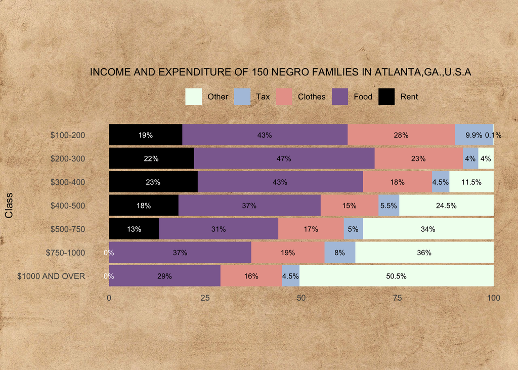

```r
income_long$category <- factor(income_long$category, levels =c ("Other", "Tax", "Clothes", "Food", "Rent"))

income_long$Class <- factor(income_long$Class, levels = c("$1000 AND OVER","$750-1000","$500-750","$400-500","$300-400","$200-300","$100-200"))

p<-ggplot(income_long, aes(x=percentage, y=Class,fill=category))+

  geom_col(position = "stack")+
  scale_fill_manual(values=c( "Other" = "#F0FFF0",
  "Tax" = "#B0C4DE",
  "Clothes" = "#E8A298",
  "Food" = "#8D6C9F",
  "Rent" = "black"))+
  theme_minimal(base_size = 10)+
  theme (panel.grid.minor = element_blank(),
         panel.grid.major = element_blank(),
         legend.position = "top",
         aspect.ratio = 0.4,
         axis.title.x = element_blank(),
         plot.title = element_text(size = 10))+
geom_text(aes( label = paste0(percentage,"%"),
    color = case_when(
    category == "Rent" ~ "white",
    TRUE ~ "black")),
  position = position_stack(vjust = 0.5),
  size = 2.5,) +
scale_color_identity()+
labs(fill = NULL,
     title = "INCOME AND EXPENDITURE OF 150 NEGRO FAMILIES IN ATLANTA,GA.,U.S.A")
# The following background rendering code was adapted from online sources.
grid::grid.raster(img, width = unit(1, "npc"), height = unit(1, "npc"))
print(p, newpage = FALSE)
```

## 2 - COVID survey - interpret

**Note**

Age and Gender Effects:  
In general, individuals aged 21–30 showed the highest level of agreement with the statement “Getting the vaccine will make me feel safer at work.” Interestingly, respondents under the age of 20 expressed greater confidence in the safety of the vaccine. Regarding gender, differences between male and female participants were relatively minor. However, individuals identifying as non-binary, third gender, or those who preferred not to disclose their gender exhibited somewhat lower levels of vaccine confidence overall.

Race and Ethnicity Effects:  
The influence of race on vaccine attitudes was more complex. On average, Asian respondents reported higher levels of confidence in the vaccine, whereas American Indian and Alaska Native respondents showed lower confidence. Native Hawaiian and other Pacific Islander respondents demonstrated strong support for the vaccine, particularly in recommending it to family, friends, and community members. In contrast, White and Black/African American respondents were generally less likely to recommend the vaccine. Regarding ethnicity, differences between Non-Hispanic/Non-Latino and Hispanic/Latino respondents were modest. However, Hispanic/Latino individuals were somewhat more likely to recommend the vaccine to others.

Vaccination History Effects:  
Having received the COVID-19 or flu vaccine had a significant impact on respondents’ attitudes. Those who had received both vaccines tended to express more trust in the vaccine and a greater willingness to recommend it to others—despite also reporting some concerns about safety and side effects. Notably, individuals who had received the COVID-19 vaccine were more likely to agree with the statement “Getting the vaccine will make me feel safer at work” and reported higher confidence in the scientific vetting process behind the new COVID vaccines.

## 3 - COVID survey - reconstruct

```r
covid_survey <- read_csv(here("data","covid-survey.csv"))
```

```
──────────────────────────────────────────────────────── Delimiter: "," chr
(14): likert_survey, ...2, ...3, ...4, ...5, ...6, ...7, ...8, ...9, ......
```

```r
glimpse(covid_survey)
```

```
Rows: 1,122
Columns: 14
$ likert_survey <chr> "response_id", "1", "2", "3", "4", "5", "6", "7", "8", "…
$ ...2          <chr> "exp_profession", "1", "1", NA, "1", "1", "1", "1", "1",…
$ ...3          <chr> "exp_flu_vax", "1", "1", NA, "1", "1", "1", "1", "1", "1…
$ ...4          <chr> "exp_gender", "0", "1", NA, "0", "0", "1", "1", "0", "0"…
$ ...5          <chr> "exp_race", "2", "2", NA, "5", "5", "5", "5", "5", "5", …
$ ...6          <chr> "exp_ethnicity", "2", "2", NA, "2", "2", "2", "2", "2", …
$ ...7          <chr> "exp_age_bin", "25", "20", NA, "25", "25", "25", "25", "…
$ ...8          <chr> "exp_already_vax", "1", "1", NA, "1", "1", "1", "1", "1"…
$ ...9          <chr> "resp_safety", "5", "5", NA, "5", "5", "5", "5", "4", "4…
$ ...10         <chr> "resp_confidence_science", "2", "1", NA, "1", "1", "1", …
$ ...11         <chr> "resp_concern_safety", "2", "1", NA, "1", "1", "1", "1",…
$ ...12         <chr> "resp_feel_safe_at_work", "1", "1", NA, "1", "1", "1", "…
$ ...13         <chr> "resp_will_recommend", "1", "1", NA, "1", "1", "1", "1",…
$ ...14         <chr> "resp_trust_info", "1", "1", NA, "1", "1", "1", "2", "2"…
```

```r
covid <- read_csv(here("data", "covid-survey.csv"), skip = 1)
dim(covid)
```

```
[1] 1121   14
```

```r
covid_clean <- covid |>
  filter(! if_all (-response_id, is.na))
dim(covid_clean)
```

```
[1] 1111   14
```

```r
covid_relabeled <- covid_clean |>
  mutate(exp_already_vax = recode(exp_already_vax,
         `0` = "No", `1` = "Yes"),
         exp_flu_vax = recode (exp_flu_vax,
         `0` = "No", `1` = "Yes"),
         exp_profession = recode (exp_profession,
         `0` = "Medical", `1` = "Nursing"),
         exp_gender = recode (exp_gender,
         `0` = "Male", `1` = "Female",
         `3` = "Non-binary third gender", `4` = "Prefer not to say",),
         exp_race = recode (exp_race,
         `1` = "American Indian / Alaskan Native", `2` = "Asian",`3` =            "Black / African American",`4` = "Native Hawaiian / Other\nPacific Islander", `5` = "White",),
         exp_ethnicity = recode (exp_ethnicity,
         `1` = "Hispanic / Latino", `2` = "Non-Hispanic/Non-Latino"),
         exp_age_bin = recode (exp_age_bin,
          `0` = "<20", `20` = "21–25", `25` = "26–30",`30` = ">30"))
glimpse(covid_relabeled)
```

```
Rows: 1,111
Columns: 14
$ response_id             <dbl> 1, 2, 4, 5, 6, 7, 8, 9, 10, 11, 12, 13, 14, 15…
$ exp_profession          <chr> "Nursing", "Nursing", "Nursing", "Nursing", "N…
$ exp_flu_vax             <chr> "Yes", "Yes", "Yes", "Yes", "Yes", "Yes", "Yes…
$ exp_gender              <chr> "Male", "Female", "Male", "Male", "Female", "F…
$ exp_race                <chr> "Asian", "Asian", "White", "White", "White", "…
$ exp_ethnicity           <chr> "Non-Hispanic/Non-Latino", "Non-Hispanic/Non-L…
$ exp_age_bin             <chr> "26–30", "21–25", "26–30", "26–30", "26–30", "…
$ exp_already_vax         <chr> "Yes", "Yes", "Yes", "Yes", "Yes", "Yes", "Yes…
$ resp_safety             <dbl> 5, 5, 5, 5, 5, 5, 4, 4, 5, 5, 5, 5, 5, 5, 5, 3…
$ resp_confidence_science <dbl> 2, 1, 1, 1, 1, 1, 2, 2, 1, 1, 2, 1, 1, 1, 1, 4…
$ resp_concern_safety     <dbl> 2, 1, 1, 1, 1, 1, 4, 4, 1, 2, 2, 3, 1, 3, 1, 4…
$ resp_feel_safe_at_work  <dbl> 1, 1, 1, 1, 1, 1, 1, 1, 1, 1, 1, 1, 1, 1, 1, 3…
$ resp_will_recommend     <dbl> 1, 1, 1, 1, 1, 1, 1, 1, 1, 1, 1, 1, 1, 1, 1, 3…
$ resp_trust_info         <dbl> 1, 1, 1, 1, 1, 2, 2, 2, 1, 1, 1, 1, 1, 1, 1, 4…
```

```r
# The following pivot_longer code was adapted from homework website
covid_survey_longer <- covid_relabeled |>
  pivot_longer(
    cols = starts_with("exp_"),
    names_to = "explanatory",
    values_to = "explanatory_value"
  ) |>
  filter(!is.na(explanatory_value)) |>
  pivot_longer(
    cols = starts_with("resp_"),
    names_to = "response",
    values_to = "response_value"
  )
print(covid_survey_longer)
```

```
# A tibble: 43,428 × 5
   response_id explanatory    explanatory_value response          response_value
         <dbl> <chr>          <chr>             <chr>                      <dbl>
 1           1 exp_profession Nursing           resp_safety                    5
 2           1 exp_profession Nursing           resp_confidence_…              2
 3           1 exp_profession Nursing           resp_concern_saf…              2
 4           1 exp_profession Nursing           resp_feel_safe_a…              1
 5           1 exp_profession Nursing           resp_will_recomm…              1
 6           1 exp_profession Nursing           resp_trust_info                1
 7           1 exp_flu_vax    Yes               resp_safety                    5
 8           1 exp_flu_vax    Yes               resp_confidence_…              2
 9           1 exp_flu_vax    Yes               resp_concern_saf…              2
10           1 exp_flu_vax    Yes               resp_feel_safe_a…              1
# ℹ 43,418 more rows
```

**Note**

For the first pivot_longer, the code organizes all variables whose names start with “exp_”. These variable names are gathered into a new column called “explanatory”, and their corresponding values are placed in a column named “explanatory_value”.

For the second pivot_longer, the code organizes all variables whose names start with “resp_”. These variable names are gathered into a new column called “response”, and their corresponding values are placed in a column named “response_value”.

```r
covid_survey_summary_stats_by_group <- covid_survey_longer |>
  group_by(explanatory,explanatory_value,response)|>
  summarise(mean = mean (response_value, na.rm = TRUE),
            low = quantile(response_value, 0.1, na.rm = TRUE),
            high = quantile(response_value, 0.9, na.rm = TRUE),
            .group = "drop")|>
  select(-.group)
print(covid_survey_summary_stats_by_group)
```

```
# A tibble: 126 × 6
# Groups:   explanatory, explanatory_value [21]
   explanatory explanatory_value response                 mean   low  high
   <chr>       <chr>             <chr>                   <dbl> <dbl> <dbl>
 1 exp_age_bin 21–25             resp_concern_safety      3.32     2     5
 2 exp_age_bin 21–25             resp_confidence_science  1.31     1     2
 3 exp_age_bin 21–25             resp_feel_safe_at_work   1.20     1     2
 4 exp_age_bin 21–25             resp_safety              1.95     1     5
 5 exp_age_bin 21–25             resp_trust_info          1.29     1     2
 6 exp_age_bin 21–25             resp_will_recommend      1.09     1     1
 7 exp_age_bin 26–30             resp_concern_safety      3.35     1     5
 8 exp_age_bin 26–30             resp_confidence_science  1.40     1     2
 9 exp_age_bin 26–30             resp_feel_safe_at_work   1.29     1     2
10 exp_age_bin 26–30             resp_safety              2.16     1     5
# ℹ 116 more rows
```

```r
covid_survey_summary_stats_all <- covid_survey_longer |>
  group_by(response)|>
  summarise(mean = mean (response_value, na.rm = TRUE),
            low = quantile(response_value, 0.1, na.rm = TRUE),
            high = quantile(response_value, 0.9, na.rm = TRUE),
            .group = "drop")|>
   mutate(explanatory = "All",
    explanatory_value = "All")|>
    select(-.group)
print(covid_survey_summary_stats_all)
```

```
# A tibble: 6 × 6
  response                 mean   low  high explanatory explanatory_value
  <chr>                   <dbl> <dbl> <dbl> <chr>       <chr>
1 resp_concern_safety      3.28     1     5 All         All
2 resp_confidence_science  1.43     1     2 All         All
3 resp_feel_safe_at_work   1.36     1     2 All         All
4 resp_safety              2.03     1     5 All         All
5 resp_trust_info          1.40     1     2 All         All
6 resp_will_recommend      1.21     1     2 All         All
```

```r
covid_survey_summary_stats <- bind_rows(
  covid_survey_summary_stats_all,
  covid_survey_summary_stats_by_group)
print(covid_survey_summary_stats)
```

```
# A tibble: 132 × 6
   response                 mean   low  high explanatory explanatory_value
   <chr>                   <dbl> <dbl> <dbl> <chr>       <chr>
 1 resp_concern_safety      3.28     1     5 All         All
 2 resp_confidence_science  1.43     1     2 All         All
 3 resp_feel_safe_at_work   1.36     1     2 All         All
 4 resp_safety              2.03     1     5 All         All
 5 resp_trust_info          1.40     1     2 All         All
 6 resp_will_recommend      1.21     1     2 All         All
 7 resp_concern_safety      3.32     2     5 exp_age_bin 21–25
 8 resp_confidence_science  1.31     1     2 exp_age_bin 21–25
 9 resp_feel_safe_at_work   1.20     1     2 exp_age_bin 21–25
10 resp_safety              1.95     1     5 exp_age_bin 21–25
# ℹ 122 more rows
```

```r
covid_survey_summary_stats <- covid_survey_summary_stats |>
  mutate(explanatory = factor(explanatory, levels = c("All","exp_age_bin", "exp_gender","exp_race","exp_ethnicity","exp_profession","exp_already_vax","exp_flu_vax")))

response_labels <- c(resp_safety = "Based on my understanding, I believe the vaccine is safe",
resp_confidence_science = "I am confident in the scientific vetting process for the new COVID vaccines",
resp_feel_safe_at_work = "Getting the vaccine will make me feel safer at work",
resp_will_recommend = "I will recommend the vaccine to family, friends, and community members",
resp_trust_info = "I trust the information that I have received about the vaccines",
resp_concern_safety = "I am concerned about the safety and side effects of the vaccine")

explanatory_labels <- c( exp_age_bin = "Age",
                         exp_gender = "Gender",
                         exp_race = "Race",
                         exp_ethnicity = "Ethnicity",
                         exp_profession = "Profession",
                         exp_already_vax = "Had COVID vaccine",
                         exp_flu_vax = "Had flu vaccine this year",
                         All = "All" )
```

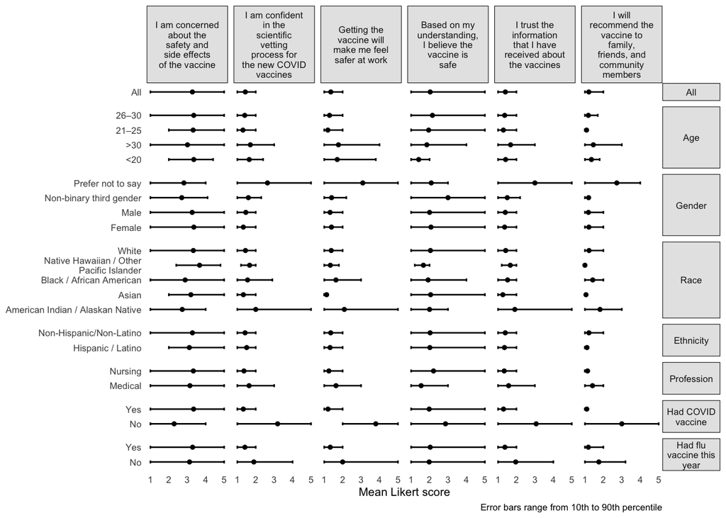

```r
ggplot(covid_survey_summary_stats, aes(x = mean, y = explanatory_value))+
  geom_errorbar(aes(xmin =low, xmax = high), width = 0.2)+
  geom_point(size = 1)+
  facet_grid(explanatory ~ response, scales ="free_y", space ="free_y",
# The following labeller code was adapted from homework website and online sourse
             labeller = labeller(response = as_labeller(response_labels,              default = label_wrap_gen(15)),
             explanatory = as_labeller(explanatory_labels,
             default = label_wrap_gen(15))))+

  labs(x = "Mean Likert score", y = NULL,
    caption = "Error bars range from 10th to 90th percentile")+
  theme_minimal(base_size = 8)+
  theme(panel.grid = element_blank(),
        strip.background = element_rect(fill = "gray90"),
        strip.text.y.right = element_text(angle = 0))
```

## 4 - COVID survey - re-reconstruct

```r
covid_survey_summary_stats_by_group_2 <- covid_survey_longer |>
  group_by(explanatory,explanatory_value,response)|>
  summarise(mean = mean (response_value, na.rm = TRUE),
            low = quantile(response_value, 0.25, na.rm = TRUE),
            high = quantile(response_value, 0.75, na.rm = TRUE),
            .group = "drop")|>
  select(-.group)
print(covid_survey_summary_stats_by_group)
```

```
# A tibble: 126 × 6
# Groups:   explanatory, explanatory_value [21]
   explanatory explanatory_value response                 mean   low  high
   <chr>       <chr>             <chr>                   <dbl> <dbl> <dbl>
 1 exp_age_bin 21–25             resp_concern_safety      3.32     2     5
 2 exp_age_bin 21–25             resp_confidence_science  1.31     1     2
 3 exp_age_bin 21–25             resp_feel_safe_at_work   1.20     1     2
 4 exp_age_bin 21–25             resp_safety              1.95     1     5
 5 exp_age_bin 21–25             resp_trust_info          1.29     1     2
 6 exp_age_bin 21–25             resp_will_recommend      1.09     1     1
 7 exp_age_bin 26–30             resp_concern_safety      3.35     1     5
 8 exp_age_bin 26–30             resp_confidence_science  1.40     1     2
 9 exp_age_bin 26–30             resp_feel_safe_at_work   1.29     1     2
10 exp_age_bin 26–30             resp_safety              2.16     1     5
# ℹ 116 more rows
```

```r
covid_survey_summary_stats_all_2 <- covid_survey_longer |>
  group_by(response)|>
  summarise(mean = mean (response_value, na.rm = TRUE),
            low = quantile(response_value, 0.25, na.rm = TRUE),
            high = quantile(response_value, 0.75, na.rm = TRUE),
            .group = "drop")|>
   mutate(explanatory = "All",
    explanatory_value = "All")|>
    select(-.group)
print(covid_survey_summary_stats_all)
```

```
# A tibble: 6 × 6
  response                 mean   low  high explanatory explanatory_value
  <chr>                   <dbl> <dbl> <dbl> <chr>       <chr>
1 resp_concern_safety      3.28     1     5 All         All
2 resp_confidence_science  1.43     1     2 All         All
3 resp_feel_safe_at_work   1.36     1     2 All         All
4 resp_safety              2.03     1     5 All         All
5 resp_trust_info          1.40     1     2 All         All
6 resp_will_recommend      1.21     1     2 All         All
```

```r
covid_survey_summary_stats_2 <- bind_rows(
  covid_survey_summary_stats_all_2,
  covid_survey_summary_stats_by_group_2)
print(covid_survey_summary_stats)
```

```
# A tibble: 132 × 6
   response                 mean   low  high explanatory explanatory_value
   <chr>                   <dbl> <dbl> <dbl> <fct>       <chr>
 1 resp_concern_safety      3.28     1     5 All         All
 2 resp_confidence_science  1.43     1     2 All         All
 3 resp_feel_safe_at_work   1.36     1     2 All         All
 4 resp_safety              2.03     1     5 All         All
 5 resp_trust_info          1.40     1     2 All         All
 6 resp_will_recommend      1.21     1     2 All         All
 7 resp_concern_safety      3.32     2     5 exp_age_bin 21–25
 8 resp_confidence_science  1.31     1     2 exp_age_bin 21–25
 9 resp_feel_safe_at_work   1.20     1     2 exp_age_bin 21–25
10 resp_safety              1.95     1     5 exp_age_bin 21–25
# ℹ 122 more rows
```

```r
covid_survey_summary_stats_2 <- covid_survey_summary_stats_2 |>
  mutate(explanatory = factor(explanatory, levels = c("All","exp_age_bin", "exp_gender","exp_race","exp_ethnicity","exp_profession","exp_already_vax","exp_flu_vax")))

response_labels <- c(resp_safety = "Based on my understanding, I believe the vaccine is safe",
resp_confidence_science = "I am confident in the scientific vetting process for the new COVID vaccines",
resp_feel_safe_at_work = "Getting the vaccine will make me feel safer at work",
resp_will_recommend = "I will recommend the vaccine to family, friends, and community members",
resp_trust_info = "I trust the information that I have received about the vaccines",
resp_concern_safety = "I am concerned about the safety and side effects of the vaccine")

explanatory_labels <- c( exp_age_bin = "Age",
                         exp_gender = "Gender",
                         exp_race = "Race",
                         exp_ethnicity = "Ethnicity",
                         exp_profession = "Profession",
                         exp_already_vax = "Had COVID vaccine",
                         exp_flu_vax = "Had flu vaccine this year",
                         All = "All" )
```

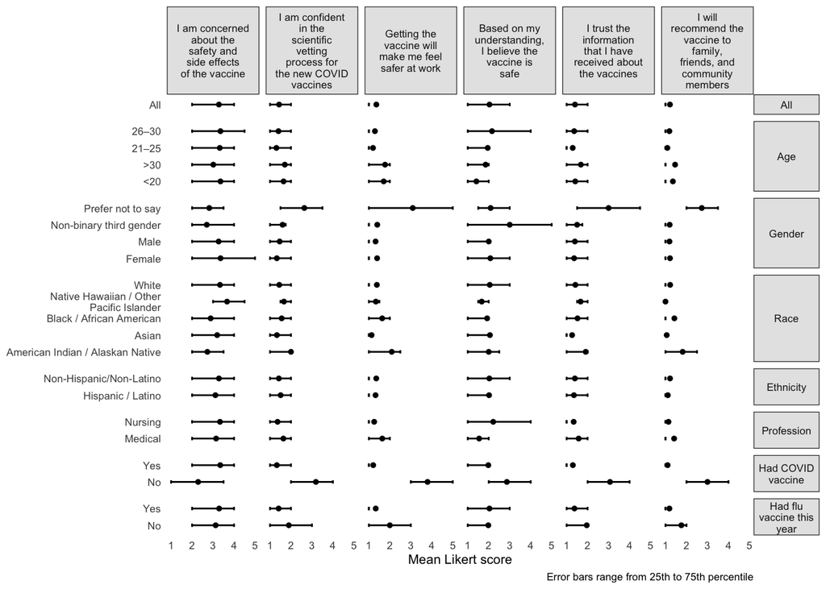

```r
ggplot(covid_survey_summary_stats_2, aes(x = mean, y = explanatory_value))+
  geom_errorbar(aes(xmin =low, xmax = high), width = 0.2)+
  geom_point(size = 1)+
  facet_grid(explanatory ~ response, scales ="free_y", space ="free_y",
# The following labeller code was adapted from homework website and online sourse
             labeller = labeller(response = as_labeller(response_labels,              default = label_wrap_gen(15)),
             explanatory = as_labeller(explanatory_labels,
             default = label_wrap_gen(15))))+

  labs(x = "Mean Likert score", y = NULL,
    caption = "Error bars range from 25th to 75th percentile")+
  theme_minimal(base_size = 8)+
  theme(panel.grid = element_blank(),
        strip.background = element_rect(fill = "gray90"),
        strip.text.y.right = element_text(angle = 0))
```

**Note**

## 5 - COVID survey - another view

```r
covid_long <- covid_relabeled |>
  pivot_longer(
    cols = starts_with("resp_"),
    names_to = "response",
    values_to = "response_value")|>
filter(!is.na(response_value))
print(covid_long)
```

```
# A tibble: 5,977 × 10
   response_id exp_profession exp_flu_vax exp_gender exp_race exp_ethnicity
         <dbl> <chr>          <chr>       <chr>      <chr>    <chr>
 1           1 Nursing        Yes         Male       Asian    Non-Hispanic/Non-…
 2           1 Nursing        Yes         Male       Asian    Non-Hispanic/Non-…
 3           1 Nursing        Yes         Male       Asian    Non-Hispanic/Non-…
 4           1 Nursing        Yes         Male       Asian    Non-Hispanic/Non-…
 5           1 Nursing        Yes         Male       Asian    Non-Hispanic/Non-…
 6           1 Nursing        Yes         Male       Asian    Non-Hispanic/Non-…
 7           2 Nursing        Yes         Female     Asian    Non-Hispanic/Non-…
 8           2 Nursing        Yes         Female     Asian    Non-Hispanic/Non-…
 9           2 Nursing        Yes         Female     Asian    Non-Hispanic/Non-…
10           2 Nursing        Yes         Female     Asian    Non-Hispanic/Non-…
# ℹ 5,967 more rows
# ℹ 4 more variables: exp_age_bin <chr>, exp_already_vax <chr>, response <chr>,
#   response_value <dbl>
```

```r
diverging <- covid_long |>
  count(response, response_value)|>
  group_by (response)|>
  mutate(percentage = n/sum(n))|>
  ungroup()
print(diverging)
```

```
# A tibble: 30 × 4
   response                response_value     n percentage
   <chr>                            <dbl> <int>      <dbl>
 1 resp_concern_safety                  1   116     0.117
 2 resp_concern_safety                  2   238     0.239
 3 resp_concern_safety                  3   110     0.111
 4 resp_concern_safety                  4   312     0.314
 5 resp_concern_safety                  5   218     0.219
 6 resp_confidence_science              1   694     0.697
 7 resp_confidence_science              2   229     0.230
 8 resp_confidence_science              3    32     0.0321
 9 resp_confidence_science              4    23     0.0231
10 resp_confidence_science              5    18     0.0181
# ℹ 20 more rows
```

```r
diverging <- diverging |>
  mutate(
    direction = case_when(
      response_value %in% c("1", "2") ~ "negative",
      response_value == "3" ~ "neutral",
      response_value %in% c("4", "5") ~ "positive"),
    percentage_value = case_when(
      direction == "negative" ~ -percentage,
      TRUE ~ percentage),
     response_value = factor(response_value, levels = c("1", "2", "3", "4", "5")))
print(diverging)
```

```
# A tibble: 30 × 6
   response           response_value     n percentage direction percentage_value
   <chr>              <fct>          <int>      <dbl> <chr>                <dbl>
 1 resp_concern_safe… 1                116     0.117  negative           -0.117
 2 resp_concern_safe… 2                238     0.239  negative           -0.239
 3 resp_concern_safe… 3                110     0.111  neutral             0.111
 4 resp_concern_safe… 4                312     0.314  positive            0.314
 5 resp_concern_safe… 5                218     0.219  positive            0.219
 6 resp_confidence_s… 1                694     0.697  negative           -0.697
 7 resp_confidence_s… 2                229     0.230  negative           -0.230
 8 resp_confidence_s… 3                 32     0.0321 neutral             0.0321
 9 resp_confidence_s… 4                 23     0.0231 positive            0.0231
10 resp_confidence_s… 5                 18     0.0181 positive            0.0181
# ℹ 20 more rows
```

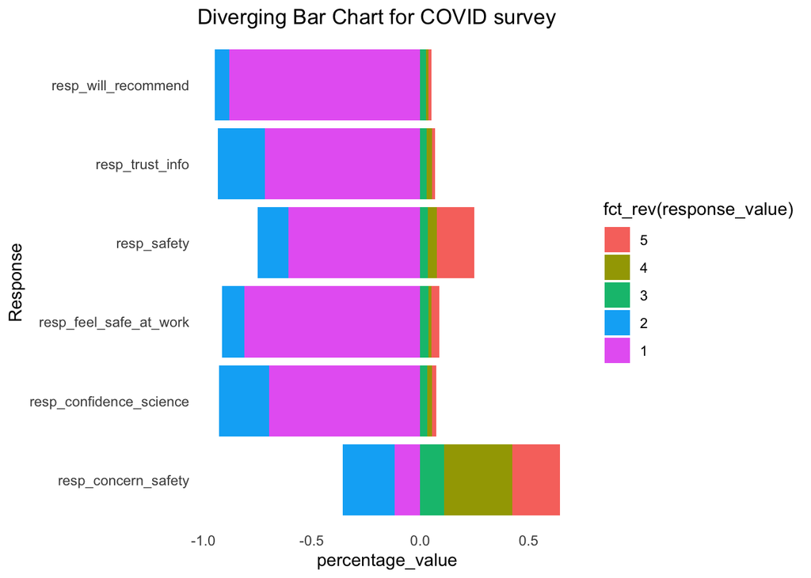

```r
ggplot(diverging, aes(x = percentage_value, y=response, fill=fct_rev(response_value)))+
    geom_bar(stat = "identity")+
    labs(title = "Diverging Bar Chart for COVID survey",
         y = "Response")+
    theme_minimal()+
  theme(panel.grid = element_blank())
```

```r
covid_long <- covid_long |>
mutate(response_value = factor(response_value, levels = 1:5,labels = as.character(1:5)),
  response = recode(response, resp_safety = "Based on my understanding,\nI believe the vaccine is safe",
resp_confidence_science = "I am confident in the scientific vetting\nprocess for the new COVID vaccines",
resp_feel_safe_at_work = "Getting the vaccine will\nmake me feel safer at work",
resp_will_recommend = "I will recommend the vaccine to family,\nfriends, and community members",
resp_trust_info = "I trust the information that I have\nreceived about the vaccines",
resp_concern_safety = "I am concerned about the safety\nand side effects of the vaccine"))
```

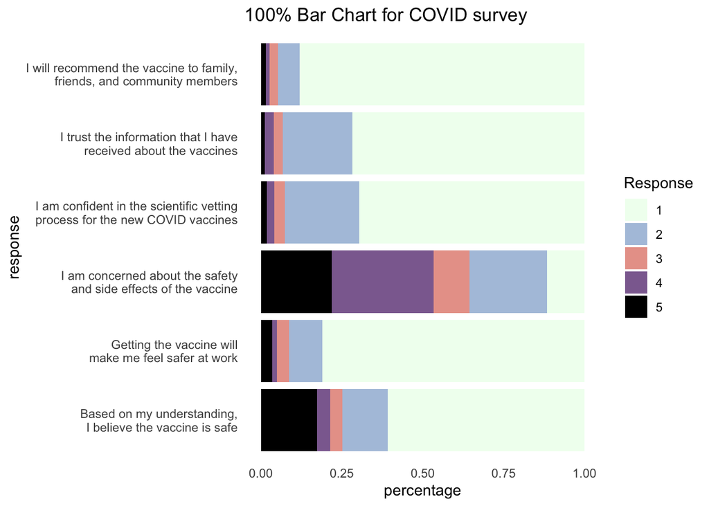

```r
ggplot(covid_long,aes(y=response, fill = response_value))+
 geom_bar(position = position_fill()) +
  labs(
    title = "100% Bar Chart for COVID survey",
    x = "percentage",
    fill = "Response") +
    scale_fill_manual(values=c( "1" = "#F0FFF0",
  "2" = "#B0C4DE",
  "3" = "#E8A298",
  "4" = "#8D6C9F",
  "5" = "black"))+
  theme_minimal()+
  theme(panel.grid = element_blank())
```

**Note**

The 100% stacked bar chart also shows responses to the COVID-19 vaccine survey, with questions on the Y-axis. Each bar represents a question and is divided into segments showing the percentage of respondents selecting each response value from 1 to 5. All bars are normalized to 100%, allowing for easy comparison of response distributions across different questions.

**Note**

Together, the two charts provide complementary views of the survey results. The diverging bar chart emphasizes the contrast between positive and negative sentiments, helping to assess overall opinion trends. In contrast, the 100% stacked bar chart focuses on the detailed distribution of all response types for each question, making it ideal for identifying variability or consistency in responses.